# Meta-analysis physiological costs of estivation: Report 8 - arousal OS

Pablo Capilla-Lasheras

2025-04-07

This [R Markdown](http://rmarkdown.rstudio.com) Notebook contains the initial meta-analysis for the project ‘physiological ’costs’ of hibernation and aestivation (this analysis is for estivation).

## Dataset and calculation of effect sizes

The dataset for this meta-analysis has been collected after a literature search by Pablo Burraco, Marko Prokic and Tamara Petrovic. It contains data on physiological effects of estivation in different systems. Here a quick snapshot of the first lines of the dataset:

|  | Reference | Year | Study_ID | Species | Family | Genus | Common.name | Type_of_animal | Thermoregulation | Class | Class_2 | Ver_Invert | Developmental_stage | Location | Experiment_venue | Biological.process | Tissue | Experimental_manipulation | Experimental.value | Biomarker_category | Biomarker_cat_2 | Biomarker_cat_3 | Specific_biomarker | Unit | Euthermia_N | Euthermia_M | Euthermia_SD | Euthermia_SE | Hib_N | … |
| --- | --- | --- | --- | --- | --- | --- | --- | --- | --- | --- | --- | --- | --- | --- | --- | --- | --- | --- | --- | --- | --- | --- | --- | --- | --- | --- | --- | --- | --- | --- |
| 1 | Giraud-Billoud et al 2013 | 2013 | study421 | Pomacea canaliculata | Ampullariidae | Pomacea | Apple snail | Snail | Ectothermic | Gastropoda | Arthopoda | Invertebrate | adults | Argentina | Laboratory | Estivation | kidney | none | NA | Non-enzymatic | Antioxidant | Non-enzymatic | uric acid | mmol/g | 6 | 5.853659e-02 | 0.08048780 | NA | 6 | … |
| 2 | Giraud-Billoud et al 2013 | 2013 | study421 | Pomacea canaliculata | Ampullariidae | Pomacea | Apple snail | Snail | Ectothermic | Gastropoda | Arthopoda | Invertebrate | adults | Argentina | Laboratory | Estivation | kidney | none | NA | Non-enzymatic | Antioxidant | Non-enzymatic | uric acid | mmol/g | 6 | 5.853659e-02 | 0.08048780 | NA | 6 | … |
| 3 | Samanta and Paital 2016 | 2016 | study112 | Duttaphrynus melanostictus | Bufonidae | Duttaphrynus | Asian Common Toad | Frog_toad | Ectothermic | Amphibia | Amphibia | Vertebrate | adults | India | Field | Estivation | Brain | none | male | Non-enzymatic | Antioxidant | Non-enzymatic | GSH | nmol/mg prot | 10 | 1.433198e+00 | 0.09716599 | NA | NA | … |
| 4 | Samanta and Paital 2016 | 2016 | study112 | Duttaphrynus melanostictus | Bufonidae | Duttaphrynus | Asian Common Toad | Frog_toad | Ectothermic | Amphibia | Amphibia | Vertebrate | adults | India | Field | Estivation | Gonad | none | male | Lipid_damage | Oxidative_damage | Oxidative_damage | TBARS | nmol/mg prot | 10 | 1.409091e+00 | 0.13636364 | NA | NA | … |
| 5 | Giraud-Billoud et al 2013 | 2013 | study421 | Pomacea canaliculata | Ampullariidae | Pomacea | Apple snail | Snail | Ectothermic | Gastropoda | Arthopoda | Invertebrate | adults | Argentina | Laboratory | Estivation | foot | none | NA | Non-enzymatic | Antioxidant | Non-enzymatic | uric acid | mmol/g | 6 | 2.146341e-01 | 0.28292683 | NA | 6 | … |
| 6 | Giraud-Billoud et al 2013 | 2013 | study421 | Pomacea canaliculata | Ampullariidae | Pomacea | Apple snail | Snail | Ectothermic | Gastropoda | Arthopoda | Invertebrate | adults | Argentina | Laboratory | Estivation | foot | none | NA | Non-enzymatic | Antioxidant | Non-enzymatic | uric acid | mmol/g | 6 | 2.146341e-01 | 0.28292683 | NA | 6 | … |
| 7 | Samanta and Paital 2016 | 2016 | study112 | Duttaphrynus melanostictus | Bufonidae | Duttaphrynus | Asian Common Toad | Frog_toad | Ectothermic | Amphibia | Amphibia | Vertebrate | adults | India | Field | Estivation | Gonad | none | male | Non-enzymatic | Antioxidant | Non-enzymatic | GSH | nmol/mg prot | 10 | 3.271255e+00 | 0.32388664 | NA | NA | … |
| 8 | Samanta and Paital 2016 | 2016 | study112 | Duttaphrynus melanostictus | Bufonidae | Duttaphrynus | Asian Common Toad | Frog_toad | Ectothermic | Amphibia | Amphibia | Vertebrate | adults | India | Field | Estivation | Brain | none | female | Non-enzymatic | Antioxidant | Non-enzymatic | GSH | nmol/mg prot | 10 | 1.821862e+00 | 0.38866397 | NA | NA | … |
| 9 | Samanta and Paital 2016 | 2016 | study112 | Duttaphrynus melanostictus | Bufonidae | Duttaphrynus | Asian Common Toad | Frog_toad | Ectothermic | Amphibia | Amphibia | Vertebrate | adults | India | Field | Hibernation and aestivation | Liver | none | male | Lipid_damage | Oxidative_damage | Oxidative_damage | TBARS | nmol/mg prot | 10 | 2.258824e+00 | 0.40000000 | NA | NA | … |
| 10 | Samanta and Paital 2016 | 2016 | study112 | Duttaphrynus melanostictus | Bufonidae | Duttaphrynus | Asian Common Toad | Frog_toad | Ectothermic | Amphibia | Amphibia | Vertebrate | adults | India | Field | Estivation | Liver | none | female | Lipid_damage | Oxidative_damage | Oxidative_damage | TBARS | nmol/mg prot | 10 | 2.729412e+00 | 0.42352941 | NA | NA | … |

[output cut: 506 more lines]

As a summary of the *initial dataset*:

- Number of studies: 21
- Number of species: 12

For this initial meta-analysis, I am going to include all oxidative stress (OS) markers and calculate the standarised mean difference (g) as the effect size of analysis comparing **arousal after estivation** *versus* **euthermia**. Positive SMD values indicate higher OS values in *arousal after estivation* while negative SMD indicate lower OS values in estivation. This is a summary of the effect size calculation based on the dataset above:

Summary of SMD effect size and number of observations included in the meta-analysis:

```
## Length  Class   Mode
##      0   NULL   NULL
```

- Number of observation with non-missing SMD: 387
- Number of studies in the dataset for analysis: 14
- Number of species in the dataset for analysis: 7

## Initial meta-analysis:

This initial model contains only the intercept and five random effects to account for variation between between classes, families, species, between studies and within studies beyond sampling variance.

```r
model_SMD <- rma.mv(yi = SMDH_arousal,
                    V = SMDH.sv_arousal,
                    mods = ~ 1,
                    random = list(~1|Study_ID,
                                  ~1|Class,
                                  ~1|Family,
                                  ~1|Species,
                                  ~1|obsID),
                    control=list(optimizer="BFGS"),
                    data=df_SMD,
                    method="REML")
```

```
##
## Multivariate Meta-Analysis Model (k = 387; method: REML)
##
##    logLik   Deviance        AIC        BIC       AICc
## -701.4853  1402.9707  1414.9707  1438.7057  1415.1923
##
## Variance Components:
##
##             estim    sqrt  nlvls  fixed    factor
## sigma^2.1  0.1430  0.3782     14     no  Study_ID
## sigma^2.2  0.0000  0.0020      2     no     Class
## sigma^2.3  0.0000  0.0002      5     no    Family
## sigma^2.4  0.0000  0.0017      7     no   Species
## sigma^2.5  1.0765  1.0375    387     no     obsID
##
## Test for Heterogeneity:
## Q(df = 386) = 1240.3130, p-val < .0001
##
## Model Results:
##
## estimate      se    zval    pval    ci.lb   ci.ub
##   0.0345  0.1289  0.2677  0.7889  -0.2181  0.2871
##
## ---
## Signif. codes:  0 '***' 0.001 '**' 0.01 '*' 0.05 '.' 0.1 ' ' 1
```

Proportion of variation left after accounting for sampling variance and proportion accounted by each random effect:

| Variable | i2_value_percentage |
| --- | --- |
| I2_Total | 72.538 |
| I2_Study_ID | 8.506 |
| I2_Class | 0.000 |
| I2_Family | 0.000 |
| I2_Species | 0.000 |
| I2_obsID | 64.032 |

### Plot of results of intercept-only model:

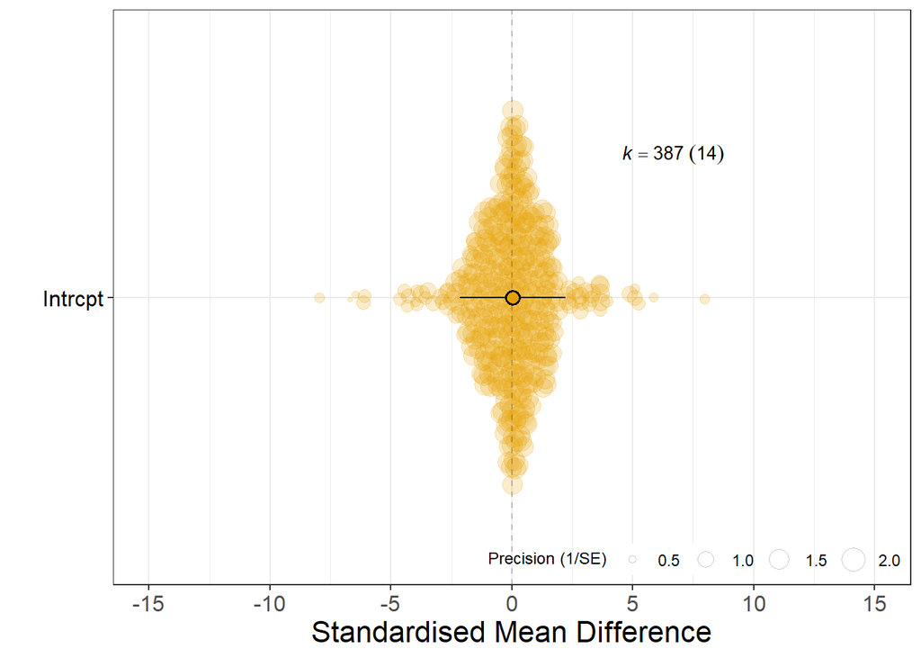

### Publication bias: small-study effects

```
##
## Multivariate Meta-Analysis Model (k = 387; method: REML)
##
##    logLik   Deviance        AIC        BIC       AICc
## -699.8279  1399.6558  1413.6558  1441.3285  1413.9529
##
## Variance Components:
##
##             estim    sqrt  nlvls  fixed    factor
## sigma^2.1  0.1718  0.4145     14     no  Study_ID
## sigma^2.2  0.0000  0.0001      2     no     Class
## sigma^2.3  0.0000  0.0000      5     no    Family
## sigma^2.4  0.0000  0.0002      7     no   Species
## sigma^2.5  1.0759  1.0373    387     no     obsID
##
## Test for Residual Heterogeneity:
## QE(df = 385) = 1231.0530, p-val < .0001
##
## Test of Moderators (coefficient 2):
## QM(df = 1) = 0.1000, p-val = 0.7518
##
## Model Results:
##
##                   estimate      se     zval    pval    ci.lb   ci.ub
## intrcpt             0.3491  1.0000   0.3491  0.7270  -1.6109  2.3091
## sqrt(inv_eff_ss)   -0.5621  1.7772  -0.3163  0.7518  -4.0454  2.9212
##
## ---
## Signif. codes:  0 '***' 0.001 '**' 0.01 '*' 0.05 '.' 0.1 ' ' 1
```

```
##    R2_marginal R2_conditional
##   0.0008780254   0.1384500115
```

### Publication bias: time-lag effects

```
##
## Multivariate Meta-Analysis Model (k = 387; method: REML)
##
##    logLik   Deviance        AIC        BIC       AICc
## -699.0822  1398.1645  1412.1645  1439.8372  1412.4615
##
## Variance Components:
##
##             estim    sqrt  nlvls  fixed    factor
## sigma^2.1  0.1175  0.3429     14     no  Study_ID
## sigma^2.2  0.0000  0.0001      2     no     Class
## sigma^2.3  0.0000  0.0000      5     no    Family
## sigma^2.4  0.0000  0.0001      7     no   Species
## sigma^2.5  1.0851  1.0417    387     no     obsID
##
## Test for Residual Heterogeneity:
## QE(df = 385) = 1225.3845, p-val < .0001
##
## Test of Moderators (coefficient 2):
## QM(df = 1) = 1.4285, p-val = 0.2320
##
## Model Results:
##
##              estimate      se    zval    pval    ci.lb   ci.ub
## intrcpt        0.0330  0.1207  0.2730  0.7849  -0.2037  0.2696
## scale(Year)    0.1362  0.1140  1.1952  0.2320  -0.0872  0.3597
##
## ---
## Signif. codes:  0 '***' 0.001 '**' 0.01 '*' 0.05 '.' 0.1 ' ' 1
```

```
##    R2_marginal R2_conditional
##     0.01519936     0.11145640
```

## Meta-analysis with all organisms but including different OS markers:

Number of observations for each type:

```
##
##      Antioxidant Oxidative_damage       Regulatory              ROS
##              303               71                8                5
```

```
##
## Multivariate Meta-Analysis Model (k = 387; method: REML)
##
##    logLik   Deviance        AIC        BIC       AICc
## -696.5322  1393.0644  1411.0644  1446.5967  1411.5470
##
## Variance Components:
##
##             estim    sqrt  nlvls  fixed    factor
## sigma^2.1  0.1861  0.4314     14     no  Study_ID
## sigma^2.2  0.0000  0.0001      2     no     Class
## sigma^2.3  0.0000  0.0000      5     no    Family
## sigma^2.4  0.0000  0.0001      7     no   Species
## sigma^2.5  1.0729  1.0358    387     no     obsID
##
## Test for Residual Heterogeneity:
## QE(df = 383) = 1240.0748, p-val < .0001
##
## Test of Moderators (coefficients 1:4):
## QM(df = 4) = 2.6805, p-val = 0.6126
##
## Model Results:
##
##                                  estimate      se     zval    pval    ci.lb
## Biomarker_cat_2Antioxidant         0.0551  0.1462   0.3770  0.7062  -0.2315
## Biomarker_cat_2Oxidative_damage   -0.0433  0.1980  -0.2185  0.8271  -0.4314
## Biomarker_cat_2Regulatory         -0.6005  0.5570  -1.0780  0.2810  -1.6922
## Biomarker_cat_2ROS                 0.5488  0.5954   0.9217  0.3567  -0.6181
##                                   ci.ub
## Biomarker_cat_2Antioxidant       0.3417
## Biomarker_cat_2Oxidative_damage  0.3448
## Biomarker_cat_2Regulatory        0.4912
## Biomarker_cat_2ROS               1.7157
##
## ---
## Signif. codes:  0 '***' 0.001 '**' 0.01 '*' 0.05 '.' 0.1 ' ' 1
```

```
##
## Multivariate Meta-Analysis Model (k = 387; method: REML)
##
##    logLik   Deviance        AIC        BIC       AICc
## -696.5322  1393.0644  1411.0644  1446.5967  1411.5470
##
## Variance Components:
##
##             estim    sqrt  nlvls  fixed    factor
## sigma^2.1  0.1861  0.4314     14     no  Study_ID
## sigma^2.2  0.0000  0.0001      2     no     Class
## sigma^2.3  0.0000  0.0000      5     no    Family
## sigma^2.4  0.0000  0.0001      7     no   Species
## sigma^2.5  1.0729  1.0358    387     no     obsID
##
## Test for Residual Heterogeneity:
## QE(df = 383) = 1240.0748, p-val < .0001
##
## Test of Moderators (coefficients 1:4):
## QM(df = 4) = 2.6805, p-val = 0.6126
##
## Model Results:
##
##                                  estimate      se     zval    pval    ci.lb
## Biomarker_cat_2Antioxidant         0.0551  0.1462   0.3770  0.7062  -0.2315
## Biomarker_cat_2Oxidative_damage   -0.0433  0.1980  -0.2185  0.8271  -0.4314
## Biomarker_cat_2Regulatory         -0.6005  0.5570  -1.0780  0.2810  -1.6922
## Biomarker_cat_2ROS                 0.5488  0.5954   0.9217  0.3567  -0.6181
##                                   ci.ub
## Biomarker_cat_2Antioxidant       0.3417
## Biomarker_cat_2Oxidative_damage  0.3448
## Biomarker_cat_2Regulatory        0.4912
## Biomarker_cat_2ROS               1.7157
##
## ---
## Signif. codes:  0 '***' 0.001 '**' 0.01 '*' 0.05 '.' 0.1 ' ' 1
```

### Plot of results of biomarker meta-regression:

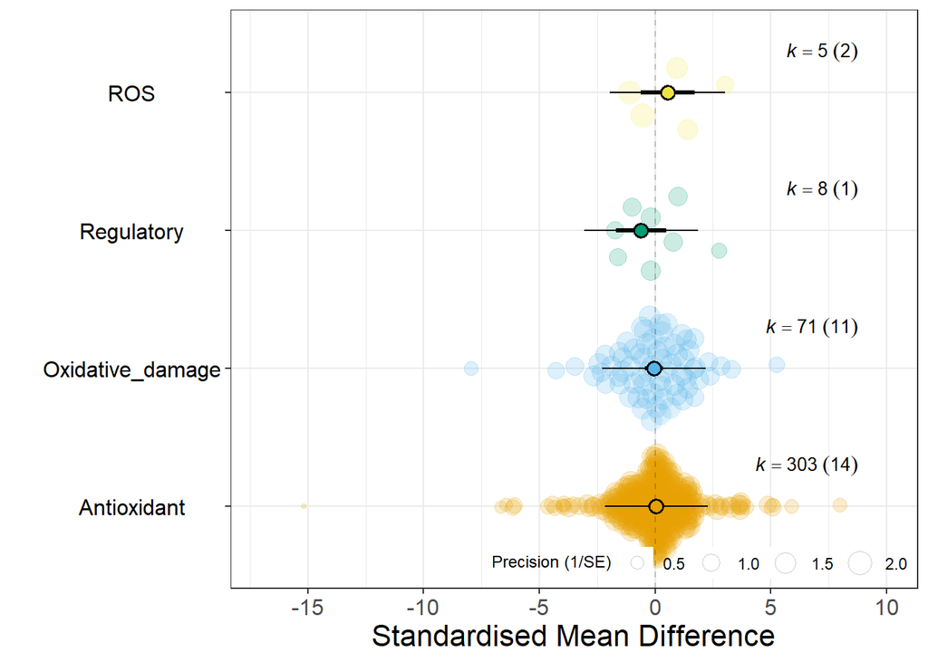

## Meta-analysis including thermoregulation type as a moderator:

Analysis can’t be done because the dataset only includes ectothermic organisms (i.e., results above refer to ectotherms).